# Content

## Content

- Introduction
- Supported Simulators
- Installing the POPdemog package
- Plotting demographic history with *PlotMS()*
  - Script input: `input.file`, `input.cmd`, and `type`
  - Scale population size: `N4`
  - Output the demographic history
- Plotting migrations
  - Using *PlotMMig()* to create an overview of migrations
  - Using *PlotMig()* to create a fine-scale migration plot
  - Adding migrations to maps
- Displaying population sizes
- More examples
  - Modified Tennessen model with Neanderthal introgression
  - Customizing the circle sizes in migration plots
  - Archaic introgression model
  - Migration model from ms
  - Ryan2009 model
  - Zigzag model
  - Demographic plot from msprime's script
  - Support for SCRM simulation script
- Acknowledgements
- References

## Introduction

Demographic history includes when and where a particular population come from, its genetic relationship to each other populations, and how its population size changes over time.

The POPdemog package produces plots which visualize population demographic history from the description of the demographic model used as input to population genetic simulator programs, such as ms [<sup>1],</sup> msHot [<sup>6],</sup> MaCS [<sup>2],</sup> and Cosi [<sup>3].</sup> Msprime's simulation scripts [<sup>7]</sup> are also supported by this package since they can be translated into ms-compatible commands. We plan to support additional simulators in the future. Please check the list of supported simulators for updates.

The POPdemog package provides three easy-to-use functions: *PlotMS()*, *PlotMMig()*, and *PlotMig()*. *PlotMS()* is the main function. It converts the demographic information from a simulation script or simulation parameter file into a plot of phylogenetic tree with arrows showing migrations between lineages. The *PlotMMig()* and *PlotMig()* functions are designed to deal with complex migration events. *PlotMMig()* gives an overview of migrations over time, and *PlotMig()* shows migrations at a specified time point in fine detail. In addition, there is a function *NRuler()* which adds a population size ruler to the plot.

This tutorial assumes that the user has some experience with a population genetics simulator program and some experience generating plots using R. An understanding of effective population size is also helpful. We will use a demographic model from Cosi to explore the power of POPdemog to visualize population history. This tutorial also includes many additional examples which show how to use the POPdemog package with different models and different simulator programs.

In this tutorial, function names are italicized [*function()*], and parameters and code is presented in mono-spaced font [`option` & `code`].

**Note:** Currently, this POPdemog package does not check the simulation program input for correctness, but assumes the simulation program input has been validated by the simulation program.

[top]

## Supported Simulators

| Simulator | Keyword | Notes |
| --- | --- | --- |
| [Cosi2](https://software.broadinstitute.org/mpg/cosi2/) | “cosi” | Use parameter file as input |
| [ms](http://home.uchicago.edu/rhudson1/source/mksamples.html) | “ms” |  |
| [msHot](http://home.uchicago.edu/rhudson1/source/mksamples.html) | “mshot” |  |
| msprime | “msprime” | Must first convert to ms-compatible input format |
| [MaCS](https://github.com/gchen98/macs) | “macs” |  |
| [SCRM](http://scrm.github.io/) | “scrm” |  |

[top]

## Installing the POPdemog package

We are working on submitting this package to the CRAN. User can also [download](https://github.com/YingZhou001/POPdemog/raw/master/POPdemog_1.0.3.tar.gz) and install it with the R command:

```
install.package("POPdemog_1.0.3.tar.gz", repos=NULL, source=TRUE)
```

For R version >= 3.3.0, package POPdemog can be installed from the source file

```
install.packages("https://github.com/YingZhou001/POPdemog/raw/master/POPdemog_1.0.3.tar.gz", repos=NULL)
```

then loaded it with

```
library(POPdemog)
```

**Note:** Safari may automatically unzip the gz file when download the package source. Please see this [page](https://apple.stackexchange.com/questions/961/how-to-stop-safari-from-unzipping-files-after-download) for how to download files with Safari without unzipping files.

[top]

## Plotting demographic history with *PlotMS()*

The *PlotMS()* function requires the `input.file` or `input.cmd`, and the `type` of the input to be specified.

###Script input: `input.file`, `input.cmd`, and `type`

The `input.file` contains all the demographic history information, it can be a copy of the simulation command line or the parameter file.

For example, the ms command line stored in a text file can be the `input.file`

```
./ms 1 1 -r 25 250001 -t 2.5 -I 4 50 50 50 60 -n 1 10 -n 2 10 -n 3 10 -n 4 10 -em 0 1 4 0.32 -em 0 4 1 0.32 -em 0 3 4 0.08 -em 0 4 3 0.08 -em 5e-04 2 1 2000 -em 6e-04 2 1 0 -ej 7e-04 2 4 -en 0.02 4 2.4 -en 0.035 1 0.77 -en 0.04 3 0.77 -en 0.1997 4 0.0125 -en 0.1998 3 0.00149253731343284 -en 0.1999 1 0.005 -ej 0.2 3 1 -em 0.1996 1 4 0 -em 0.1995 4 1 0 -em 0.1994 3 4 0 -em 0.1993 4 3 0 -en 0.3499 1 0.00117647058823529 -ej 0.35 1 4 -en 1.7 4 1.25
```

and the parameter file (from the software Cosi2) of Cosi can be the `input.file`.

```
# sample file
# comments have #s in front of them
# newlines don't matter.

#-- options that could be uncommented
#infinite_sites yes
#random_seed 12345   # Specifies a particular random number seed

# in bp.
length 250000

# per bp per generation
mutation_rate 1.5e-8

recomb_file model.out
gene_conversion_relative_rate 0.3

# population info

pop_define 1 european
pop_define 3 african-american
pop_define 4 asian
pop_define 5 african

#european
pop_size 1 100000
sample_size 1 50

#african american
pop_size 3 100000
sample_size 3 50

#asian
pop_size 4 100000
sample_size 4 50

#african
pop_size 5 100000
sample_size 5 60

pop_event migration_rate "afr->eur migration" 5 1 0. .000032
pop_event migration_rate "eur->afr migration" 1 5 0 .000032
pop_event migration_rate "afr->as migration" 5 4 0. .000008
pop_event migration_rate "as->afr migration" 4 5 0 .000008
pop_event admix "african american admix" 3 1 5. .2
pop_event split "african to aa" 5 3 7.0

pop_event change_size "agriculture - african" 5 200 24000
pop_event change_size "agriculture - european" 1 350 7700
pop_event change_size "agriculture - asian" 4 400 7700
pop_event bottleneck "african bottleneck" 5 1997 .008
pop_event bottleneck "asian bottleneck" 4 1998 .067
pop_event bottleneck "european bottleneck" 1 1999 .02

pop_event split "asian and european split" 1 4 2000
pop_event migration_rate "afr->eur migration" 5 1 1996 0
pop_event migration_rate "eur->afr migration" 1 5 1995 0
pop_event migration_rate "afr->as migration" 5 4 1994 0
pop_event migration_rate "as->afr migration" 4 5 1993 0

pop_event bottleneck "OoA bottleneck" 1 3499 .085
pop_event split "out of Africa" 5 1 3500

pop_event change_size "african pop size" 5 17000 12500
```

We will store the preceding ms command line in the file “sample.ms.cmd”, and use it in examples later in this tutorial.

We also provide the string input option `input.cmd`, which allows the user to pass the simulation command line as a string to the *PlotMS()* function. The `type` parameter must be specified to so that *PlotMS()* can interpret the input correctly.

[top]

###Scale population size: `N4` Effective population size is an important parameter in simulations with ms-like script (msHot, scrm, and MaCS). It is used to scale the population size and the time for demographic events. The `N4` parameter has the same meaning of the \(4N0\) parameter in ms, which must be specified in order to give the correct times for demographic events and the accurate sizes for populations.

The `N4` parameter is not used in two situations:  
1. when producing a topology plot with `size.scale="topology"`;  
2. when the simulation script do not re-scale the population size and time, such as is the case with Cosi.

[top]

###Output the demographic history

Now we can generate our first plot of demographic history from the ms file “sample.ms.cmd”, with `N4` set to 10000 in this case.

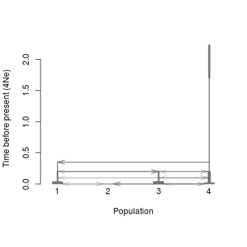

```r
PlotMS(input.file="sample.ms.cmd", type="ms", N4=10000)
```

This basic plot is usually not satisfactory. However, there are many options which will allow us to customize the output figure.

1.Adjust the lineage width with the `size.scale` parameter. Lineage width represents the population size. Here we use a logarithm function with a base of 50 to resale the population size \(N\) so that the width of the lineage is \(log_{50}(N/N4+1)\) in the plot.

```
size.scale="log", log.base =50
```

2.Adjust the population position with the `inpos` parameter (`inpos[i]` is the position of the `i`th population).

```
inpos=c(3,6,1,9)
```

3.Add color to each lineage with the `col.pop` parameter (`col.pop[i]` is the color for the $i$th population). The color of arrow is the same as the source population by default, or can be reset with the `col.arrow` parameter.

```
col.pop=c("blue", "coral3", "gold3", "brown")
```

4.Add population labels to each lineage with the `pops` parameter (`pops[i]` is the name for the `i`th population).

```
pops=c("European", "African American", "Asian", "African")
```

Adding these settings to *PlotMS()*, we have:

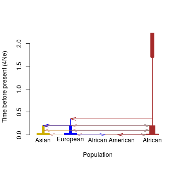

```r
PlotMS(input.file="sample.ms.cmd", type="ms", N4=10000, size.scale="log",
       log.base =50, inpos=c(3,6,1,9),
       col.pop=c("blue", "coral3", "gold3", "brown"),
       pops=c("European", "African American", "Asian", "African"))
```

If the recent events are more interesting than ancient ones, we can zoom in with

```
time.scale="log10year",
```

which will scale the y-axis as \(log_{10}(years\ before\ present)\), using default 25 years per generation. The years per generation can be defined with the `gen` parameter. We can also show only the topology structure with

```
size.scale="topology"
```

which tells the function to ignore the time and population size but still display the order of demographic events. We can also adjust the font size, axis label size, and the arrow size.

```
cex.lab=0.6
cex.axis=0.6
length.arrowtip=0.05
```

If there are too many background migrations, these events can be masked by

```
m.adjust=0.05 #mask the migration with per generation rate less than 0.05
```

Applying these adjustments, we obtain:

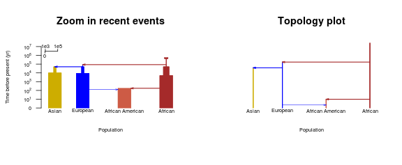

```r
par(mfrow=c(1,2), las=1)
PlotMS(input.file="sample.ms.cmd", type="ms", N4=10000,
       size.scale="log", log.base =50, inpos=c(3,6,1,9),
       col.pop=c("blue", "coral3", "gold3", "brown"),
       pops=c("European", "African American", "Asian", "African"),
       time.scale="log10year", cex.lab=0.6, cex.axis=0.6, length.arrowtip=0.05, m.adjust=0.05)
title("Zoom in recent events", cex=0.8)
NRuler("topleft", Nsize=c(1e3, 1e5), Nlab=c("1e3","1e5"), N4=10000, size.scale="log",log.base=50, lwd=1, cex=0.6)
PlotMS(input.file="sample.ms.cmd", type="ms", N4=10000,
       size.scale="topology", inpos=c(3,6,1,9),
       col.pop=c("blue", "coral3", "gold3", "brown"),
       pops=c("European", "African American", "Asian", "African"),
       cex.lab=0.6, cex.axis=0.6, length.arrowtip=0.05, ylab="Time before present", m.adjust=0.05)
title("Topology plot", cex=0.8)
```

[top]

## Plotting migrations

When there are multiple migrations at the particular time, arrows in the *PlotMS()* output might cross with the population lineages and overlap with each other. The migration events will be difficult to see in this setting, so we use function *PlotMig()* to output the migrations at a specified time in separate plots. We also have the *PlotMMig()* function to display an overview of all the migrations among simulated populations. Both of these two migration plot functions are based on the output of function *PlotMS()* with `plot.out=F` and `demo.out=T`.

[top]

###Using *PlotMMig()* to create an overview of migrations *PlotMMig()* will automatically output the direction and the duration of each migration. Plot settings are passed from function *PlotMS()* to *PlotMMig()* through the `mig_par` element of the list returned by *PlotMS()*. More information is available from the `help(PlotMS)` command in R.

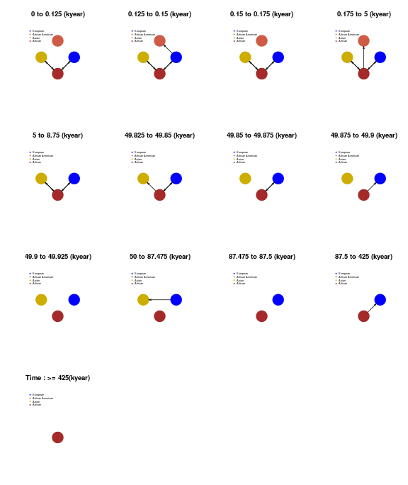

```r
#output the demographic information from PlotMS
out<-PlotMS(input.file="sample.ms.cmd", type="ms", N4=10000, size.scale="log",
        log.base =50, col.arrow="black", time.scale="kyear",
        col.pop=c("blue", "coral3", "gold3", "brown"),
        pops=c("European", "African American", "Asian", "African"),
        plot.out=F, demo.out=T,
        cex.lab=0.5, cex.axis=0.6, length.arrowtip=0.05)
#plot the overview of all migrations
PlotMMig(demograph_out=out$demograph_out, mig_par=out$mig_par)
```

[top]

###Using *PlotMig()* to create a fine-scale migration plot *PlotMig()* shows migration at a specified time. It has three options for the `size.scale` parameter to scale the size of the circle according to the population size at the particular time. We can ignore the size differences by setting `size.scale="topology"` and using `toposize.scale` to customize the circle sizes on the plot. We can also set `size.scale="log"` and `size.scale="linear"` to scale the circle size according to the population size. The `"linear"` option will give circle sizes proportional to the population sizes, while the `"log"` option tends to reduce the size differences and generates circles of similar sizes. More discussion on circle sizes will be found in the section Customizing the circle sizes in migration plots.

In our next example, we plot all migrations 125 years ago (with `time_pt=125` and `time.scale="year"`). The time point(`time_pt`) units are specified by the `time.scale` parameter.

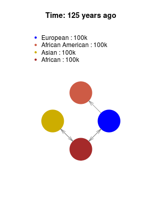

```r
out<-PlotMS(input.file="sample.ms.cmd", type="ms", N4=10000, plot.out=F, demo.out=T)
PlotMig(time_pt=125, demograph_out=out$demograph_out, mig_par=out$mig_par,
    size.scale="log", time.scale="year", log.base=20,
    col.pop=c("blue", "coral3", "gold3", "brown"),
    xlim=c(-8, 8), ylim=c(-8, 12));
N<-NOut(time_pt=125, demograph_out=out$demograph_out, time.scale="year");
legend("topleft", pch=20, col=c("blue", "coral3", "gold3", "brown"), bty="n",
       legend=paste(c("European", "African American", "Asian", "African"), " : ", N/1000, "k", sep=""), )
title(paste("Time: 125 years ago"))
```

In the Figure 5, the color and size of arrows can also be customized by the variables `col.arrow` and the `length.arrowtip`, please check the arguments with `help(PlotMig)` for more information.

[top]

###Adding migrations to maps Next, we are going to see an example of adding migration plot to a map. In this example, we need to install the `maps` package

```
install.package("maps")
```

```r
library(maps)
##initiate the world map
map('legacy_world', fill=T, col="gray45", bg="lightgray", lty=0)
axis(1);axis(2);
##the positions for the four populations
##European 50, 20
##Asian 36, 112
##African 7, 23
##African American 38, -100
inp.map.pos<-cbind(c(20, -100, 112, 23), c(50, 38, 36, 7))

out<-PlotMS(input.file="sample.ms.cmd", type="ms", N4=10000, plot.out=F, demo.out=T)
unlink("sample.ms.cmd")
times<-out$mig_par$time #time points for all events
times #output times points for all demographic events
```

```
##  [1] 0.0000 0.0005 0.0006 0.0007 0.0200 0.0350 0.0400 0.1993 0.1994 0.1995
## [11] 0.1996 0.1997 0.1998 0.1999 0.2000 0.3499 0.3500 1.7000
```

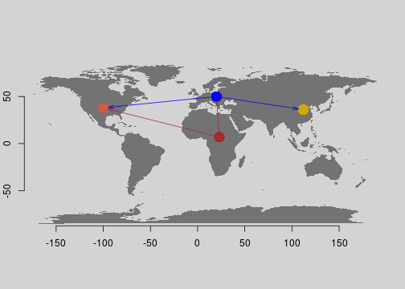

```r
for(i in times){
PlotMig(time_pt=i, demograph_out=out$demograph_out, mig_par=out$mig_par,
        size.scale="topology", col.pop=c("blue", "coral3", "gold3", "brown"),
        toposize.scale=50, add=T, map.pos=inp.map.pos, length.arrowtip=0.1, m.adjust=0.01,
        col.arrow=c("blue", "coral3", "gold3", "brown"));
}
```

[top]

## Displaying population sizes

*NRuler()* and *NOut()* are two functions to display population size. *NRuler()* adds a population size ruler to the plot, and users can customize the ruler position, ticks on the ruler, labels on the ticks, and other figure options. The *NOut()* function outputs the population size numbers. It can be used with the *legend()* function to annotate the plot with population sizes.  
See the example in the section Modified Tennessen model with Neanderthal introgression for how use these two function. Generally speaking, *NRuler()* is for the plots generated by *PlotMS()*, while *NOut()* is for the plots generated by *PlotMig()*.

##More examples

### Modified Tennessen model with Neanderthal introgression[<sup>4]</sup>

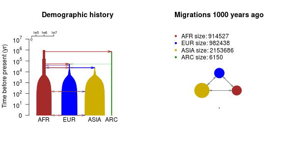

```r
cat("macs 2025 15000000 -i 10 -r 3.0e-04 -t 0.00069 -T -I 4 10 1006 1008 1 0
-n 4 0.205 -n 1 58.00274 -n 2 70.041 -n 3 187.55 -eg 0.9e-10 1 482.46
-eg 1.0e-10 2 570.18 -eg 1.1e-10 3 720.23 -em 1.2e-10 1 2 0.731
-em 1.3e-10 2 1 0.731 -em 1.4e-10 3 1 0.2281 -em 1.5e-10 1 3 0.2281
-em 1.6e-10 2 3 0.9094 -em 1.7e-10 3 2 0.9094 -eg 0.007 1 0
-en 0.007001 1 1.98 -eg 0.007002 2 89.7668 -eg 0.007003 3 113.3896
-eG 0.031456 0 -en 0.031457 2 0.1412 -en 0.031458 3 0.07579
-eM 0.031459 0 -ej 0.03146 3 2 -en 0.0314601 2 0.2546
-em 0.0314602 2 1 4.386 -em 0.0314603 1 2 4.386 -eM 0.0697669 0
-ej 0.069767 2 1 -en 0.0697671 1 1.98 -en 0.2025 1 1 -ej 0.9575923 4 1
-em 0.06765 2 4 32 -em 0.06840 2 4 0", file="model-Tennessen.cmd")
#plot the demographic graph
par(mfrow=c(1,2), las=1)
PlotMS(input.file="model-Tennessen.cmd", type="macs", N4=30000,
       size.scale="log", log.base=50, inpos=c(1,4,7,9), time.scale="log10year",
       col.pop=c("brown", "blue", "gold3", "forestgreen"),
       pops=c("AFR", "EUR", "ASIA", "ARC"), cex.lab=1, cex.axis=1, xlab="", length.arrowtip=0.1)
##add population size ruler to the plot to reflect the real population sizes
NRuler("topleft", Nsize=c(1e5,1e6,1e7), Nlab=c("1e5","1e6", "1e7"), N4=30000,
       size.scale="log",log.base=50, lwd=1, cex=0.6)
title("Demographic history")
PlotMS(input.file="model-Tennessen.cmd", type="macs", N4=30000,
       time.scale="log10year", plot.out=F, demo.out=T)->out;
#log10(1000)=3
PlotMig(time_pt=1000, time.scale="year",
        demograph_out=out$demograph_out, mig_par=out$mig_par,
        col.pop=c("brown", "blue", "gold3", "forestgreen"),
    size.scale="linear", linear.scale=0.000003,
        xlim=c(0,20), ylim=c(0,30), length.arrowtip=0.08)
##annotate the real population sizes
N<-NOut(time_pt=1000, time.scale="year", demograph_out=out$demograph_out)
legend("topleft",
       legend=paste(c("AFR", "EUR", "ASIA", "ARC"), "size:", N),
       col=c("brown", "blue", "gold3", "forestgreen"), pch=20, bty="n")
title("Migrations 1000 years ago");
```

[top]